# Water Quality

Brian Detweiler

December 23, 2016

## MUD Water Quality

The Metropolitan Utilities District is a public utilities district responsible for all of Omaha, Nebraska’s utilities, from water, to sewage, to gas (not electricity, which is handled by OPPD). MUD releases annual water quality testing reports in PDF format.

I thought it might be interesting to compile this data and visualize it.

Unfortunately, MUD only provides the summary results from the tests, not the full testing data.

The first task was to get the data into a usable format. This required a lot of copy-pasting and manual manipulation to get it out of PDF format and into a CSV. This took a few hours, and thankfully, the format was fairly consistent from year to year, which made the data collection slightly tedius but manageable.

The reports break down chemical levels into three groups - Regulated, **Unregulated**, and Minerals.

## Reproducibility

To reproduce these results, you can find the raw PDFs, the compiled data, the cleaning script, and this report at https://github.com/bdetweiler/omaha-water-quality.

# Unregulated Chemicals

## Nickel

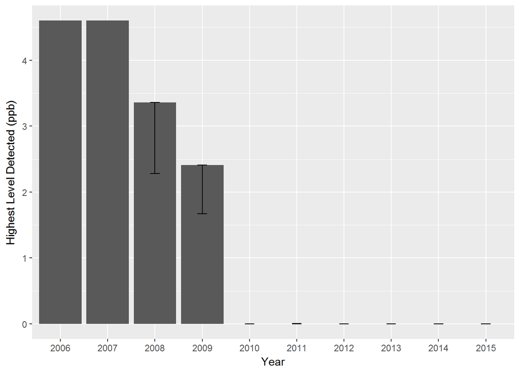

## Bromochloroacetic acid

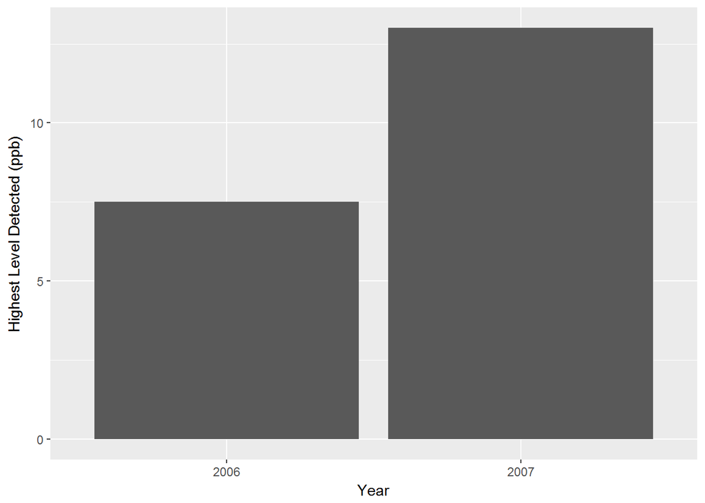

## Bromodichloromethane

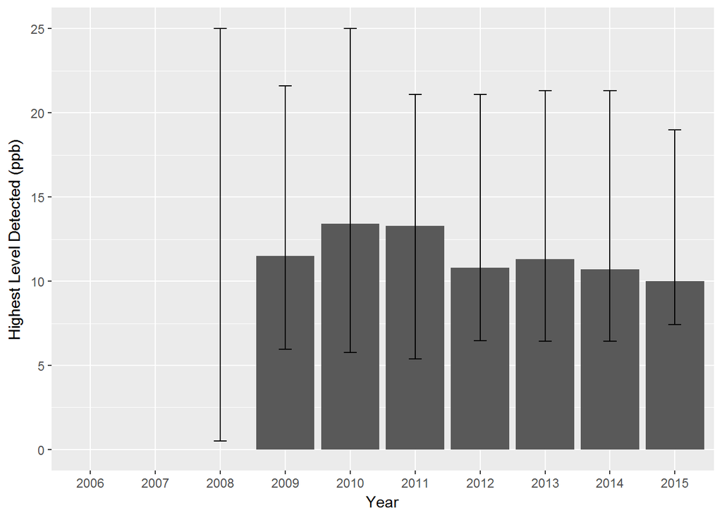

## Bromoform

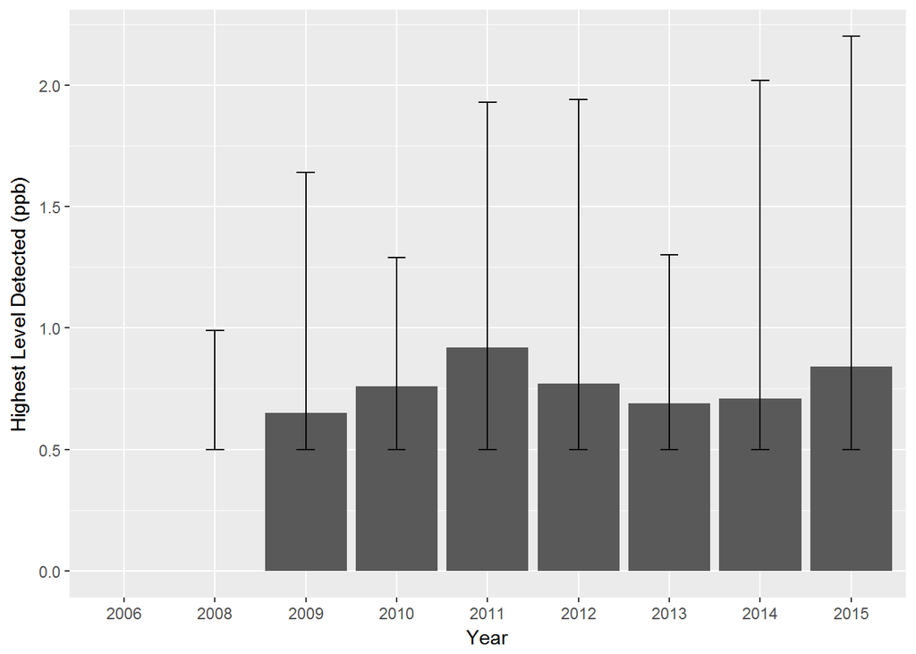

## Chloroform

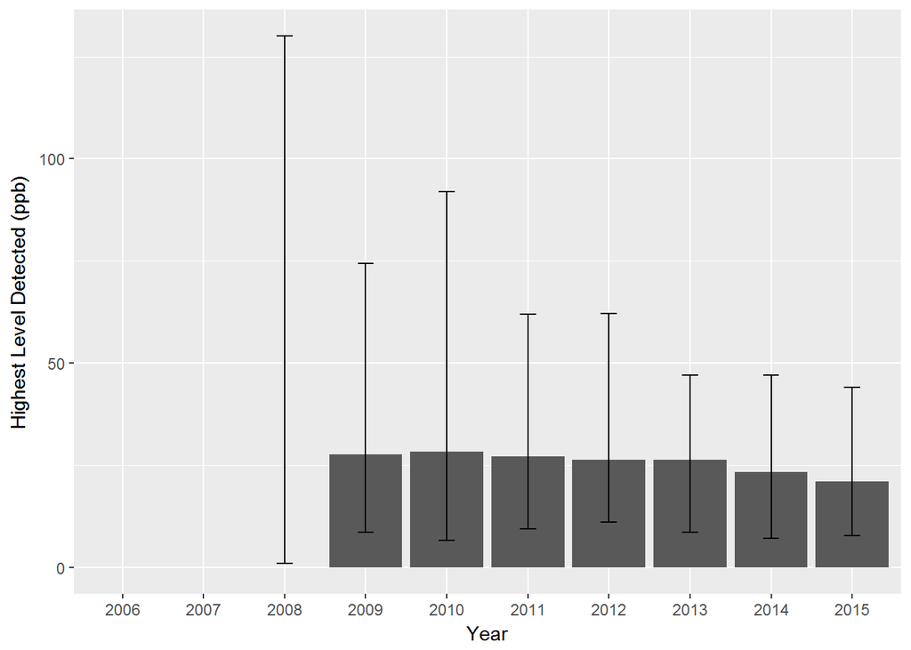

## Dibromoacetic acid

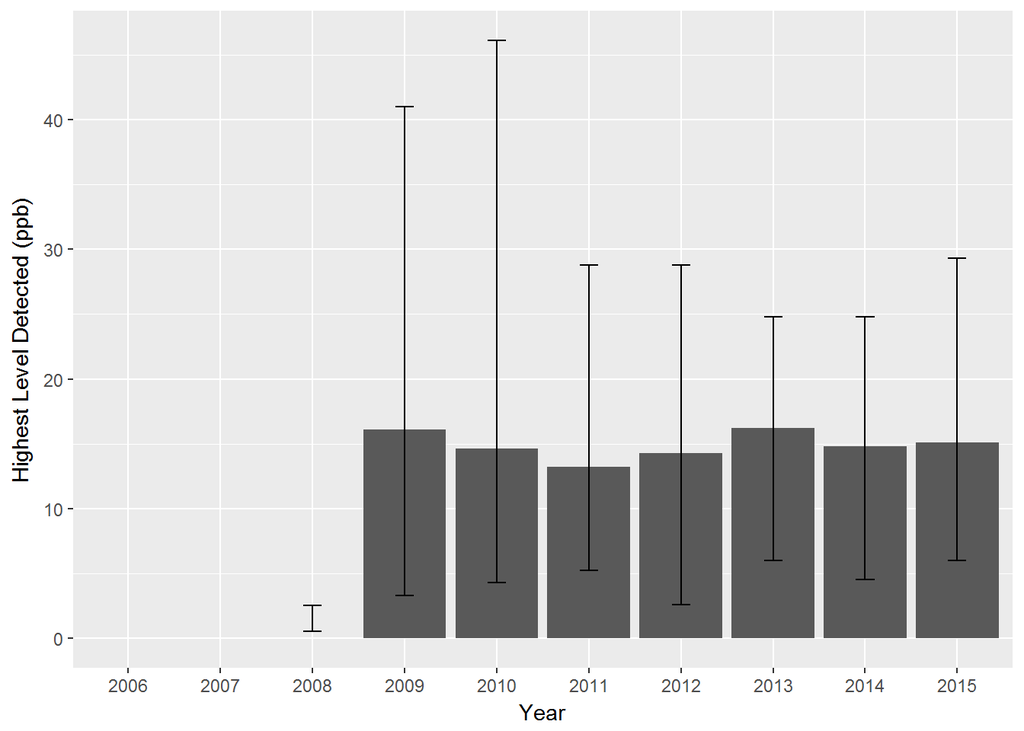

## Dibromochloromethane

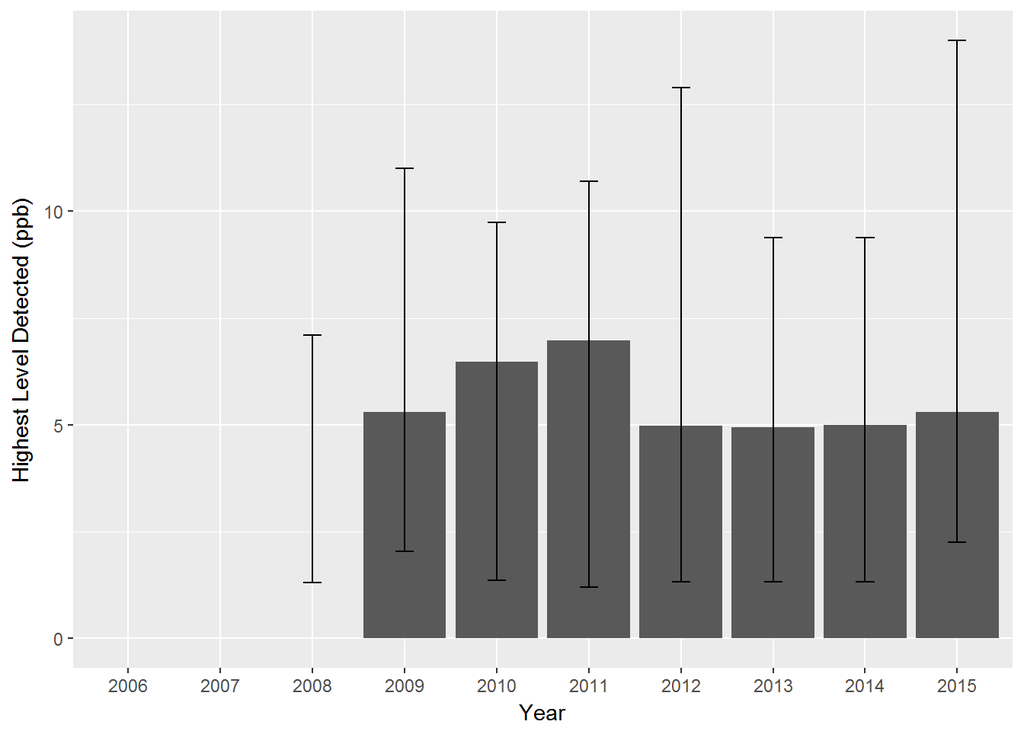

## Dichloroacetic acid

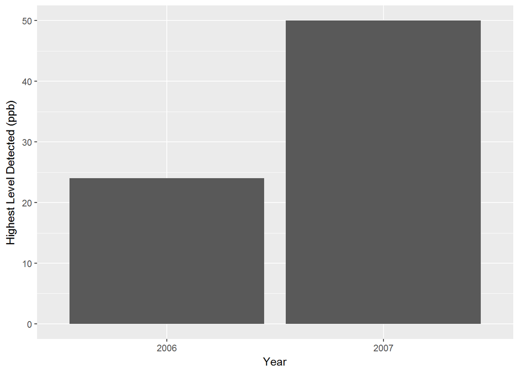

## Metolachlor

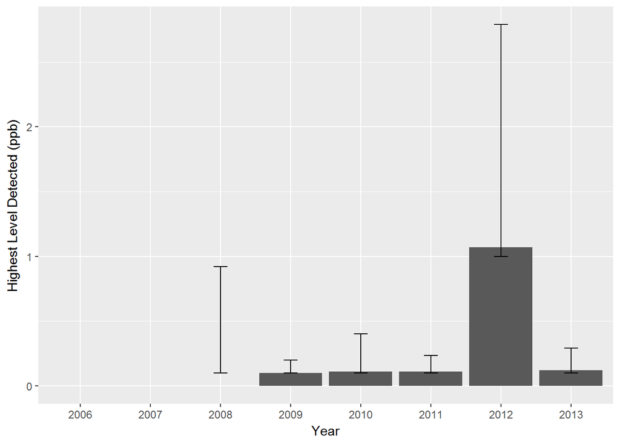

## Monochloroacetic acid

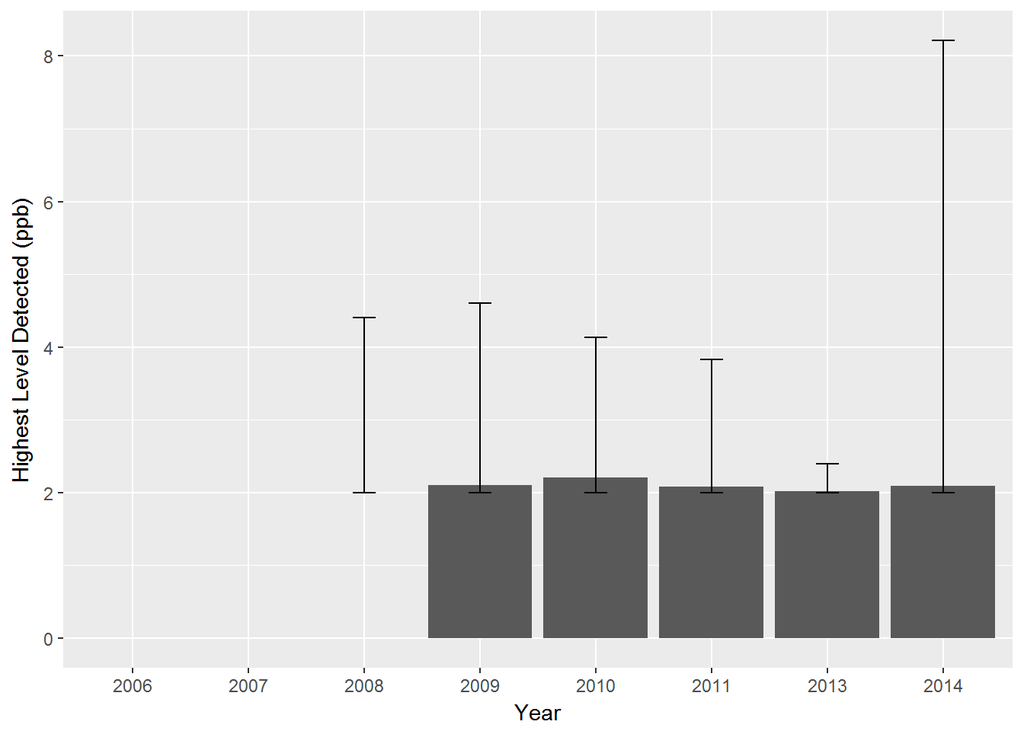

## Total Organic Carbon (TOC)

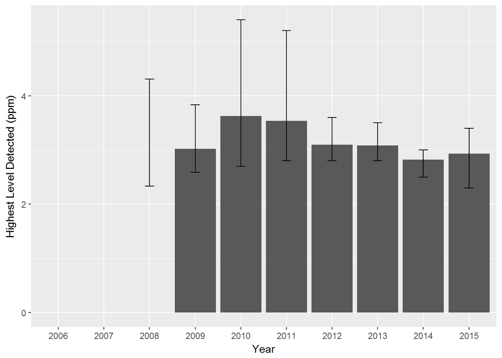

## Trichloroacetic acid

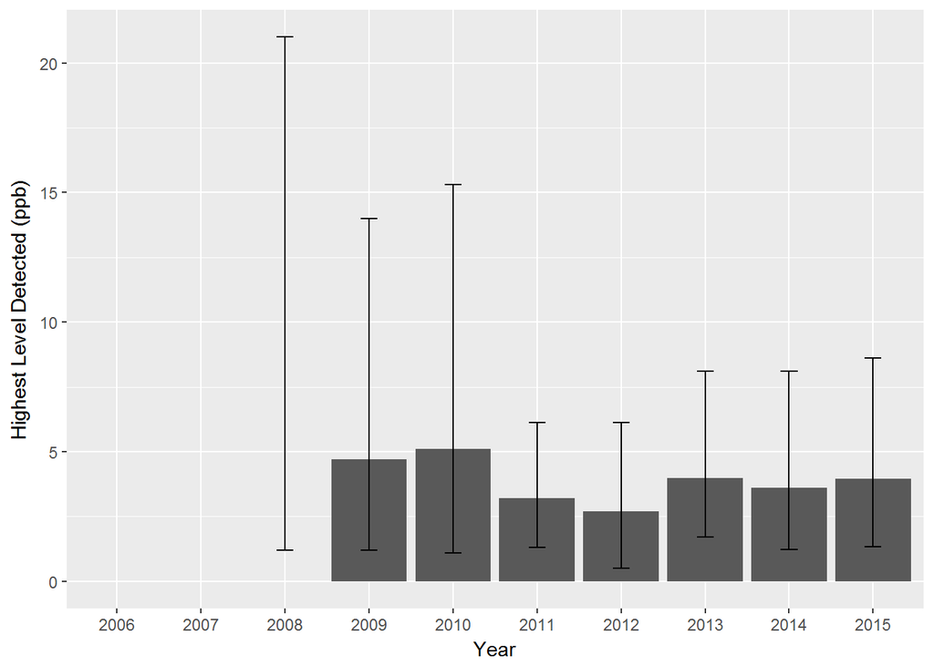

## Sulfate

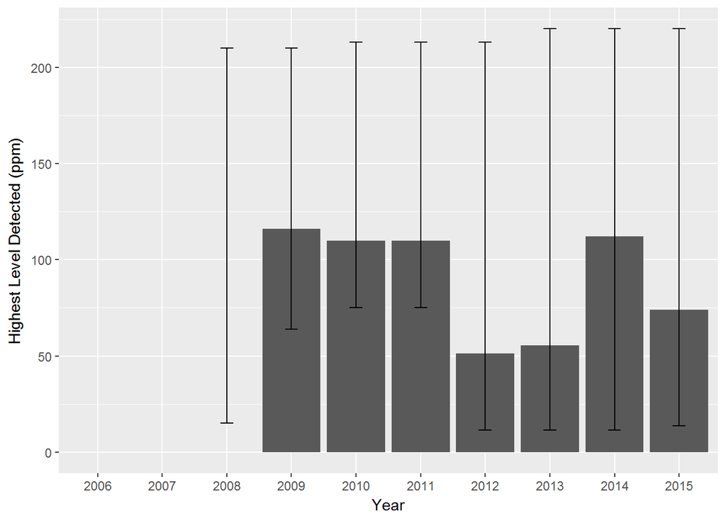

## Monobromoacetic acid

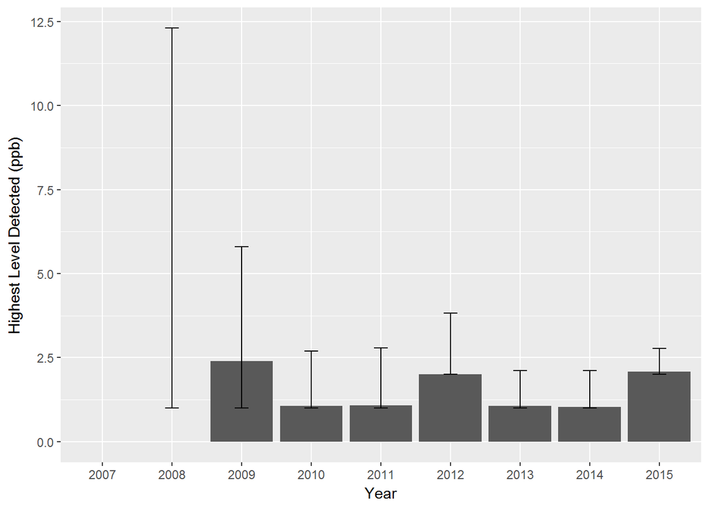

## Bromochlooacetic acid

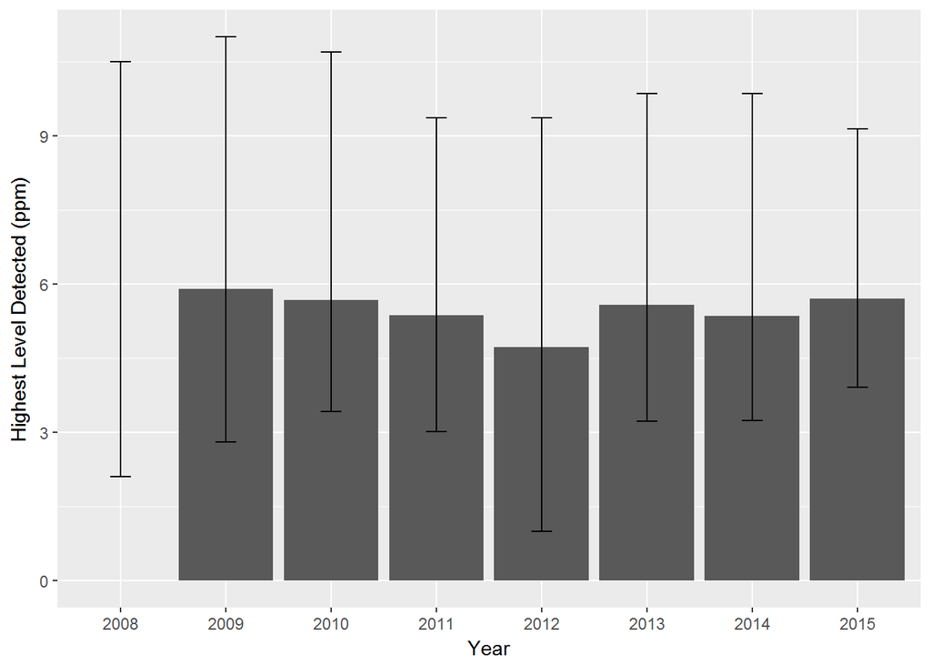

## Dichoroacetic acid

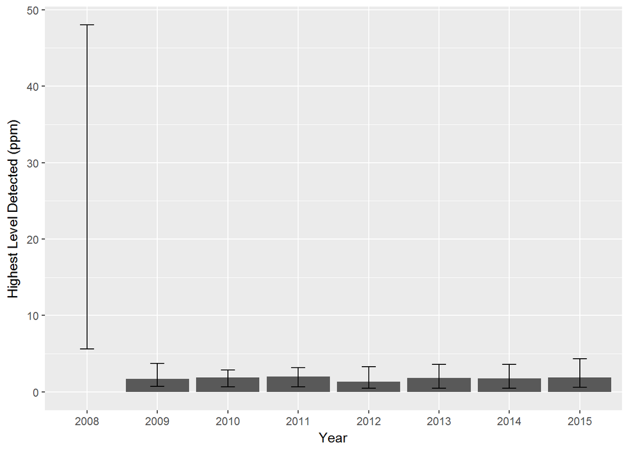

## Radium-228

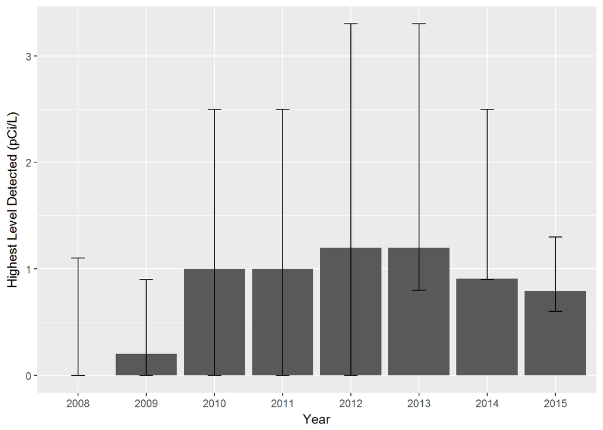

## Radium-226

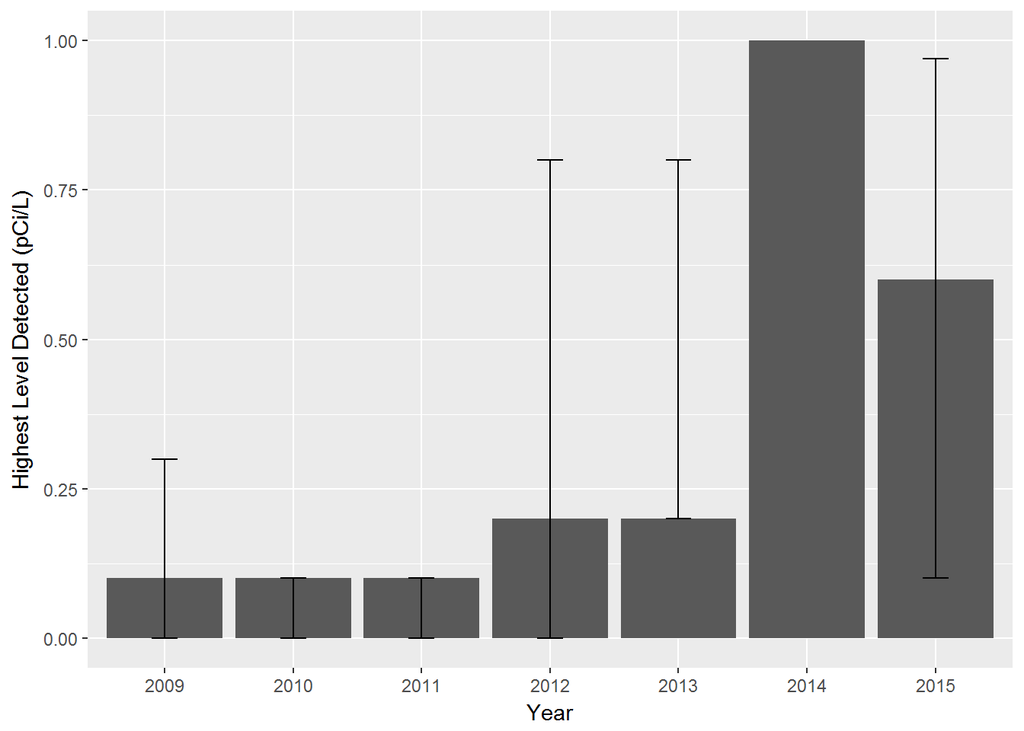

## N-Nitrosodimethylamine (NDMA)

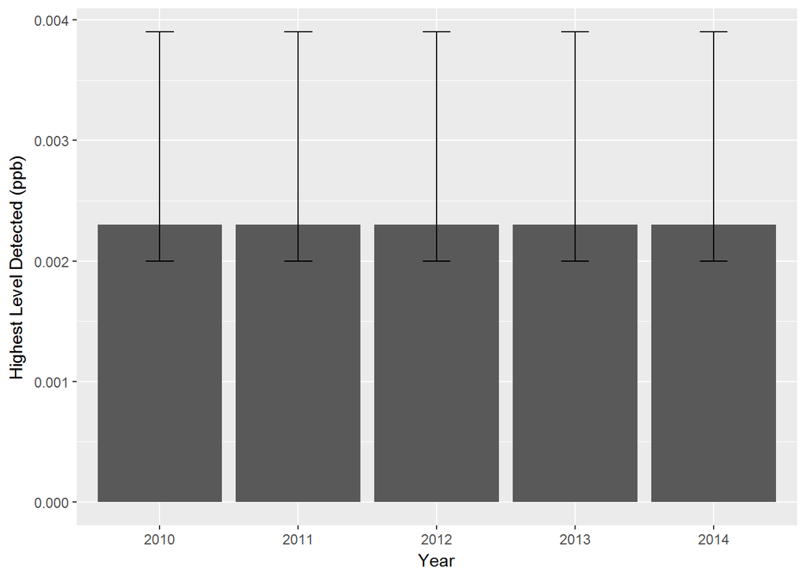

## Chlorate

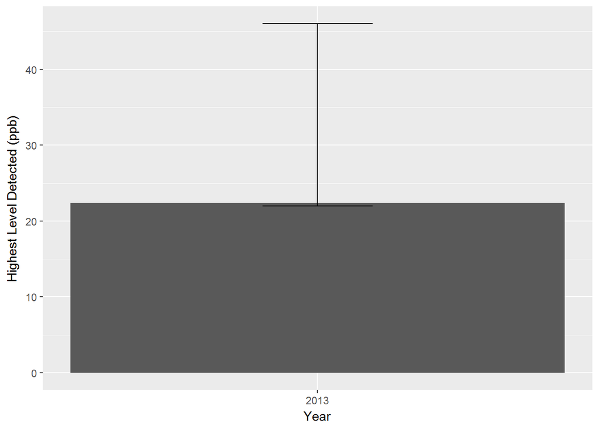

## Molybdenum

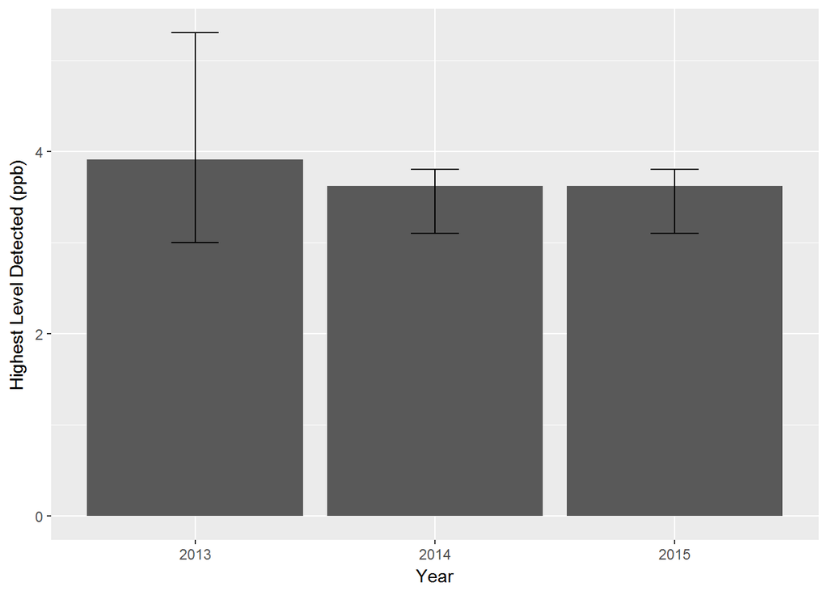

## Strontium

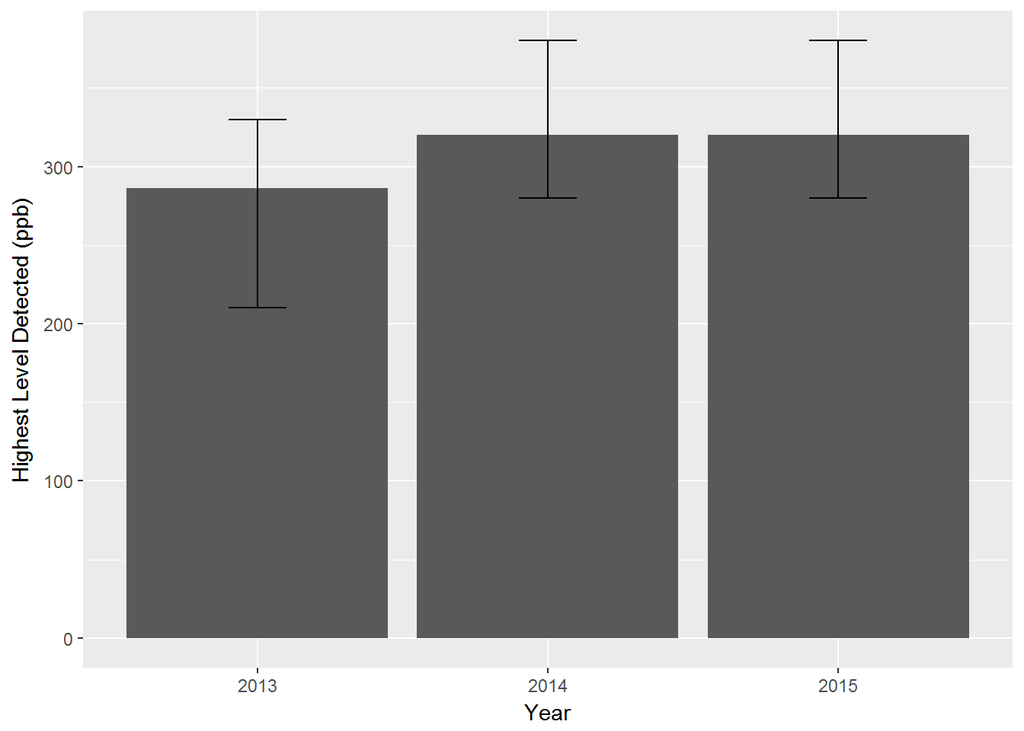

## Vanadium

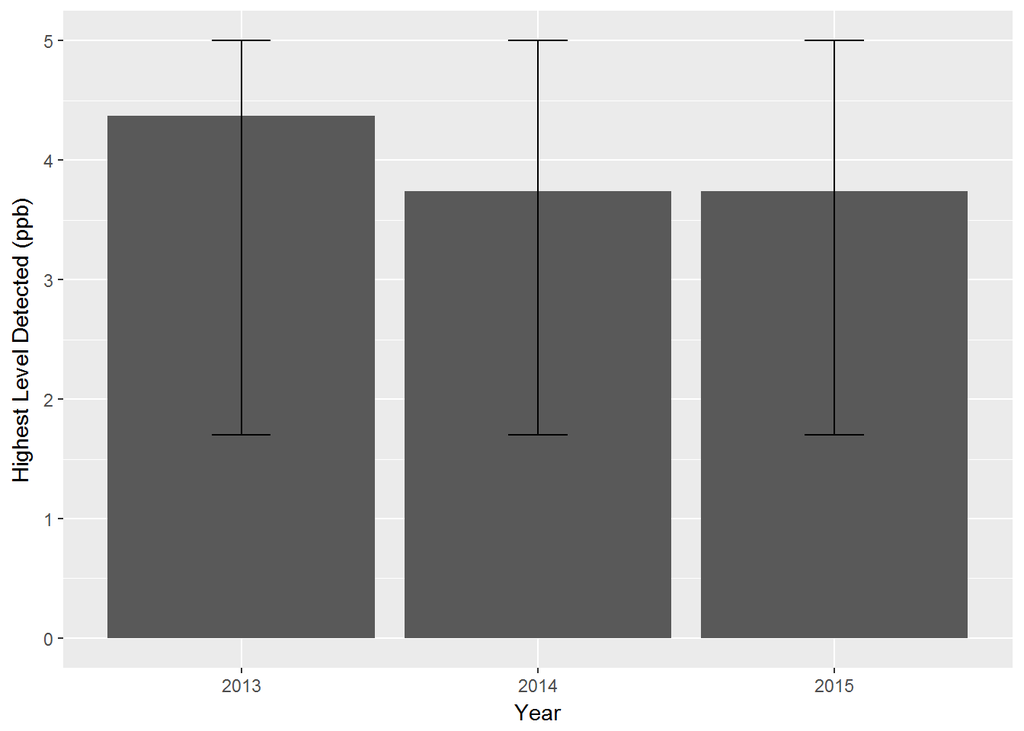